# **Final Project: Predicting CKD from Gene and Risk Factor Data**

## A Tutorial for the Data Science Lifecycle

**Member 1: Zuzanna Mamczarz**, Contribution: 95% (did not contribute to H)

**Member 2: Samirah Huda**, Contribution: 95% (did not contribute to H)

"We, all team members, agree together that the above information is true, and we are confident about our contributions to this submitted project/final tutorial."

Zuzanna Mamczarz, 5/6/2024

Samirah Huda, 5/6/2024

## Introduction

There are two unique datasets included for chronic kidney disease (CKD)- a gene dataset and a risk factor dataset, both are collected from patients. The gene and risk factor data is not collected from the same group as that data was not avaliable, however overall we are looking at various factors that contribute to CKD. We decided to focus on CKD as we originally had many datasets from many disease and it was a lot more data so we shifted to CKD, but we may consider using the additional data in the Machine learning part if we can make a relevant model, and doing further statistical analysis on that if needed.

## Part 1: Gene Data Preprocessing

**Importing datasets and cleaning data**

Gene data:

Goal- ckd regulatory gene candidates

```python
import pandas as pd
import matplotlib.pyplot as plt
import seaborn as sns
from scipy.stats import pearsonr


gene_df = pd.read_csv('GSE225890_rna_seq_by_FDR.csv')
# rename columns to differentiate control and experimental groups(this is found in dataset description but labeled badly)
gene_df= gene_df.rename(columns={'13-C':'13-E','14-C':'14-E','15-C':'15-E','16-C':'16-E','17-C':'17-E','18-C':'18-E','19-C':'19-E','20-C':'20-E','21-C':'21-E'})
print(gene_df)
#all data as floats, otherwise have names in strings (no casting into float required)
#only null names, not relevant to drop- those only describe the gene function
#theoretically, you could add the function in after searching it, but it is only necessary in genes of interest and not worth spending time doing for all ~50 missing function, as its something you can just find online if relevant
print(gene_df.info())


#The dataset did not load into Python as it was so big, but it was organized(sorted) through FDR(adjusted pvalue), so I had to manually(Excel) delete the remaining genes to load the dataset
# The genes I deleted I looked at closely, and all had a tiny foldchange(below 10)/insignifcant pvalue(above .05), thus I checked each as I went through to make sure it was not hidden useful data
#I stopped deleting at around 1500 genes, as the pvalue was becoming significant(although at 1500 it was .21 so still not helpful) and the foldchange bigger- and I was actually able to load it in python!
#We are only looking at big, significant foldchange, so nothing I would use got deleted
```

```
     Gene_symbol                                               NAME  \
0          PITX2                          paired-like homeodomain 2
1         PKNOX2                           PBX/knotted 1 homeobox 2
2          IGFN1  immunoglobulin-like and fibronectin type III d...
3           ZIC1                                Zic family member 1
4         IGFBP1       insulin-like growth factor binding protein 1
...          ...                                                ...
1540       PDE3B               phosphodiesterase 3B, cGMP-inhibited
1541        GLI2                           GLI family zinc finger 2
1542       FTSJ1     FtsJ RNA methyltransferase homolog 1 (E. coli)
1543        FZD5                          frizzled class receptor 5
1544        SIM1   single-minded family bHLH transcription factor 1

      Foldchange        PValue           FDR       22-C       23-C  \
0     137.954878  1.910000e-99  4.830000e-95   0.060390   0.467107
```

[output cut: 63 more lines]

```
    Gene_symbol                            NAME  Foldchange        PValue  \
0         PITX2       paired-like homeodomain 2  137.954878  1.910000e-99
9          ALX1                  ALX homeobox 1  645.077741  5.550000e-36
18        LYPD6   LY6/PLAUR domain containing 6   34.360361  7.960000e-21
48         SCIN                       scinderin   23.547702  3.140000e-13
131      PCDH19                protocadherin 19   13.154432  1.510000e-08
138      LYPD6B  LY6/PLAUR domain containing 6B   21.799221  1.870000e-08
179       CCKAR      cholecystokinin A receptor  119.736912  1.730000e-07
180       GATA2          GATA binding protein 2   33.111685  1.850000e-07
258        TBX4                         T-box 4   46.099810  2.790000e-06
349        ISL2              ISL LIM homeobox 2   24.222860  1.960000e-05

              FDR      22-C      23-C      24-C       13-E       14-E  \
0    4.830000e-95  0.060390  0.467107  0.137429  32.538873  34.228032
9    1.410000e-32  0.000000  0.000000  0.000000   5.784689   3.964949
```

[output cut: 79 more lines]

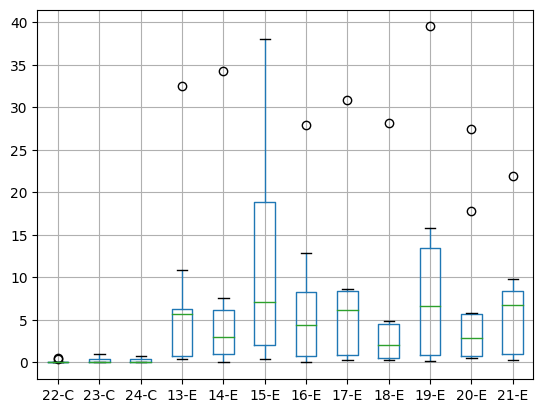

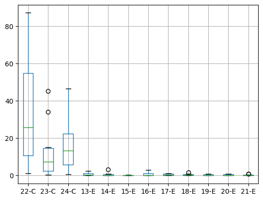

```python
#While the rest of the data is important, for our purpose, we only want to look at the most up/downregulated genes to associate the disease with
#This is a huge set, so we will find our focus and clean the data after we identify about 50 candidates for up, and 50 down

#Wanting to choose the most upregulated genes in CKD, we sort the data through the Foldchange value(amount of change between control and experimental)
gene_df.head()

#Choose top 50 upregulated(50 gives enough to find the most upregulated ones, AND significant ones to sort, ofcourse can add more if once you look at it, all are not significant), create new dataframe to work
up=pd.DataFrame
up=gene_df.sort_values("Foldchange",ascending=False)
up=up.head(50)

#sort through the most significant values(adjusted pvalue), many high fold change ones are not as significant and have outliers, so they are not as strong candidates and need to be considered later/cleaned
up=up.sort_values("FDR")
up


#up/down regulated genes have differing biological signifiance
#same as above in upreg, make new dataframe but for downregulated genes
down=pd.DataFrame
down=gene_df.sort_values("Foldchange").head(50)
down=down.sort_values("FDR")
down

#the data in each sample is amount of counts of gene expressed
#looking at the data, there are some clear outliers we can remove(ex. all 0, except one huge value in one sample= no real regulation, ex. huge differences within group, 1000 or 50= no reg)
up=up.drop([up.index[5]])
up=up.drop([up.index[2]])
#can go with top 10 candidates now that largest outliers removed, all data seem to show change(ex. control 0, exp 10)
up=up.head(10)
print(up)
col= ['22-C','23-C','24-C','13-E','14-E', '15-E', '16-E','17-E', '18-E', '19-E', '20-E', '21-E']
up.boxplot(col)
#We can look at means and general idea of distributed data, and outliers(each sample has one, but not more ) in the boxplot

down
plt.figure()
down=down.drop([down.index[3]])
down=down.drop([down.index[3]])
#We can look at means and general idea of distributed data, and outliers(we only see a couple) in the boxplot
down=down.head(10)
print(down)
down.boxplot(col)
```

## Part 2: Exploratory Data Analysis for Gene Data

**1. Pearson Correlation**

In understanding if a gene is significantly showing regulation, we want to check there is correlation in samples, and they are actually regulated in a direction. Patient data is variable as humans are naturally going to have genetic varaition, but if all samples in a group(C or E) are correlated, then a defined gene can be possibly making the changes genetically regulated.

We want to understand if these samples are correlated to themselves enough to prove its not just random genetic changes

```
          13-E      14-E      15-E      16-E      17-E      18-E      19-E  \
13-E  1.000000  0.982321  0.822179  0.945053  0.986775  0.970242  0.978813
14-E  0.982321  1.000000  0.776572  0.900882  0.979714  0.972438  0.936477
15-E  0.822179  0.776572  1.000000  0.707554  0.789558  0.673406  0.832615
16-E  0.945053  0.900882  0.707554  1.000000  0.940873  0.923640  0.969111
17-E  0.986775  0.979714  0.789558  0.940873  1.000000  0.969926  0.956209
18-E  0.970242  0.972438  0.673406  0.923640  0.969926  1.000000  0.923800
19-E  0.978813  0.936477  0.832615  0.969111  0.956209  0.923800  1.000000
20-E  0.930401  0.903519  0.923728  0.795833  0.892314  0.859118  0.901040
21-E  0.946135  0.901592  0.794232  0.972485  0.958492  0.896218  0.971094

          20-E      21-E
13-E  0.930401  0.946135
14-E  0.903519  0.901592
15-E  0.923728  0.794232
16-E  0.795833  0.972485
17-E  0.892314  0.958492
18-E  0.859118  0.896218
19-E  0.901040  0.971094
20-E  1.000000  0.830265
21-E  0.830265  1.000000
          22-C      23-C      24-C
22-C  1.000000  0.741107  0.677803
23-C  0.741107  1.000000  0.532652
24-C  0.677803  0.532652  1.000000
```

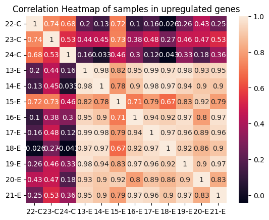

```python
#UPREGULATED GENE SAMPLES

#distinguish groups , control and ckd
treatment=['13-E','14-E', '15-E', '16-E','17-E', '18-E', '19-E', '20-E', '21-E']
control=['22-C','23-C','24-C']
#create correlation plot for each group
x=up[treatment].corr()
print(x)
y=up[control].corr()
print(y)
#visualize on heatmap
h=sns.heatmap(up[col].corr(), annot=True)
h.set_title("Correlation Heatmap of samples in upregulated genes")
plt.figure()
```

The heatmap helps visualize the correlation amongst the samples. At the top left, the lighter square of all of the control samples, shows they are more correlated amongst each other than among CKD patients. This helps understand the random variation among the genes in the people is not just random, but the similiarity is related to the genetic disease factor. Same with the ckd patients. The big light square in the bottom right shows the patients samples are correlated better than compared to controls, as those cmoparing the ckd patients and controls are darker. The darker square is closer to 0, so not correlated, and lighter is closer to 1, 1 being correlated, so you can get an idea of the whole dataset and sample group being correlated due to disease.

We beter visualize this to each individual sample in the upregulated genes below. Zooming in on an exmaple of pearson correlation in two controls, two ckd patients, and control vs ckd. You can see the pearson correlation coefficient (r) is close to 1 in the grouped samples, while it is close to 0 in the control vs ckd. A larger pairs plot is formed to get an idea of the entire data and every pair, not just a couple specific ones, showing a trend like the above heatmap

```
r= 0.7411069306809104
```

[figure not shown]

```
r= 0.7895581090844369
```

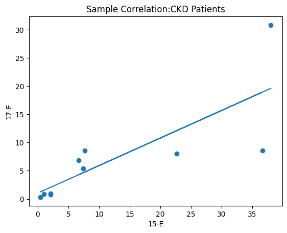

```
r= 0.11820067181188622
```

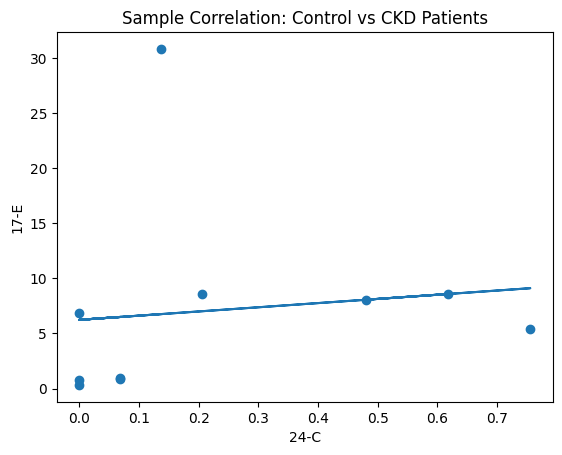

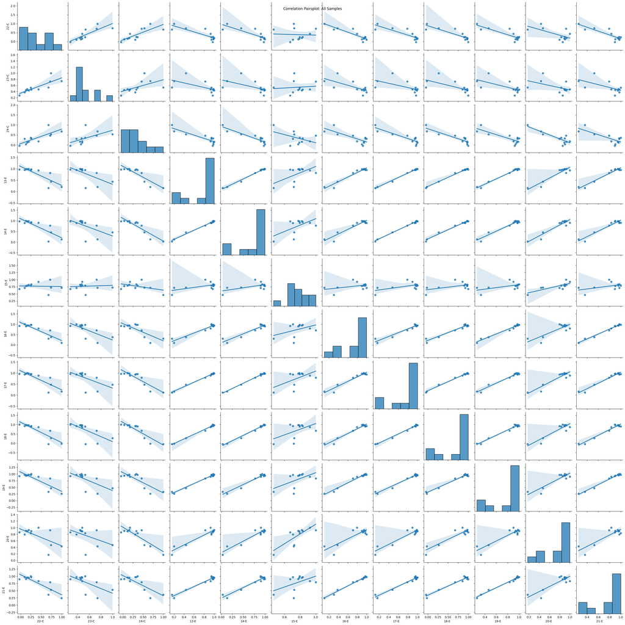

```python
import matplotlib.pyplot as plt
import numpy as np
from scipy.stats import pearsonr
#control correlation
a=up['22-C']
b=up['23-C']
corr, _ = pearsonr(a, b)
print("r=", corr)
plt.figure()
plt.scatter(a,b)
m, b =np.polyfit(a,b,1)
plt.plot(x, m*x + b)
plt.title("Sample Correlation:Controls")
plt.xlabel("22-C")
plt.ylabel("23-C")

plt.show()


#ckd correlation
d=up['15-E']
c=up['17-E']
corr, _ = pearsonr(d,c)
print("r=", corr)
plt.figure()
plt.scatter(d,c)
m, b=np.polyfit(d,c,1)
plt.plot(d,m*d+b)
plt.title("Sample Correlation:CKD Patients")
plt.xlabel("15-E")
plt.ylabel("17-E")

plt.show()

#control vs ckd
x=up['24-C']
y=up['17-E']
plt.figure()
plt.scatter(x,y)
m, b =np.polyfit(x,y,1)
plt.plot(x, m*x + b)
plt.title("Sample Correlation: Control vs CKD Patients")
plt.xlabel("24-C")
plt.ylabel("17-E")
corr, _ = pearsonr(x, y)
print("r=", corr)
plt.show()

#pairsplot
p=sns.pairplot(up[col].corr(), kind='reg')
p.fig.suptitle("Correlation Pairsplot: All Samples")
```

Overall, the above ideas are shown- there is more correlation in samples in the groups themself, then control vs ckd patients, so overall there seems to be some relation to the genes regulating disease within a group.

We do the same heatmap with the downregulated genes to glance at them, although we may focus on upregulated genes later on, since upregulated genes are more straightforward to biologically silence and "treat".

```
          13-E      14-E      15-E      16-E      17-E      18-E      19-E  \
13-E  1.000000  0.852300  0.703835  0.790300  0.583262  0.882498  0.747535
14-E  0.852300  1.000000  0.626385  0.676385  0.392572  0.847522  0.599692
15-E  0.703835  0.626385  1.000000  0.758510  0.690216  0.878202  0.822250
16-E  0.790300  0.676385  0.758510  1.000000  0.861656  0.862190  0.894065
17-E  0.583262  0.392572  0.690216  0.861656  1.000000  0.671303  0.787639
18-E  0.882498  0.847522  0.878202  0.862190  0.671303  1.000000  0.887745
19-E  0.747535  0.599692  0.822250  0.894065  0.787639  0.887745  1.000000
20-E  0.811441  0.569125  0.874627  0.804239  0.715921  0.884520  0.940115
21-E  0.701753  0.625163  0.787880  0.639949  0.462214  0.835007  0.884648

          20-E      21-E
13-E  0.811441  0.701753
14-E  0.569125  0.625163
15-E  0.874627  0.787880
16-E  0.804239  0.639949
17-E  0.715921  0.462214
18-E  0.884520  0.835007
19-E  0.940115  0.884648
20-E  1.000000  0.894805
21-E  0.894805  1.000000
          22-C      23-C      24-C
22-C  1.000000  0.480898  0.641927
23-C  0.480898  1.000000  0.935285
24-C  0.641927  0.935285  1.000000
```

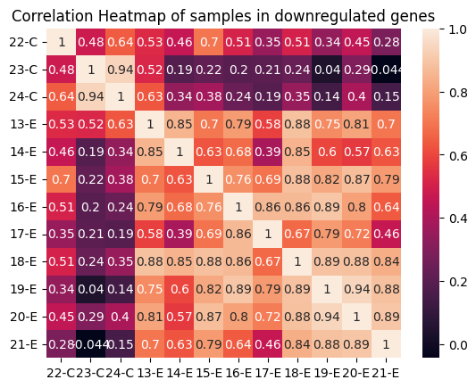

```python
#Down regulated glance at samples
x1=down[treatment].corr()
print(x1)
y1=down[control].corr()
print(y1)
h1=sns.heatmap(down[col].corr(), annot=True)
h1.set_title("Correlation Heatmap of samples in downregulated genes")
```

The downregulated genes samples are also more correlated in groups, like the upregulated genes. Seeing more correlation in the controls, and in he ckd patients, then betwen control vs ckd patients.

Overall, there is not too many samples (only 3 controls) thus natural human variation easily shows, so there is no perfect correlation among groups, but overall, there is a slight trend toward the groups being more correlated inside, then correlated to control vs ckd patient, so we can assume there are genetic relations to the disease.

# Hypothesis Testing- Mann Whitney

We want to understand whether the differences in the gene expression in groups are large enough to be understood as really upregulated and if the change in expression is relevant enough to consider disease relation to the disease.

We will peform a Mann-Whitney test, we want to compare the means of genes expressed in control and pkd patient samples. We assume the groups are independent of one another. There is so few samples, there is no way to assume normal distribution with only 3 controls-thus Mann- Whitney is ideal. We can use a significance level of .05 for the test.

The genes will be tested separately, so PTIX2 gets its own test, and ALX1 also does. The point is to look at each gene, to test if there is difference in each expression in patients in each group and determine if it is significant as a candidate gene to have relation to disease.

We will also graph the data to show the differences.

The dataset gave p-values and adjusted pvalue(FDR) itself, but I do not know how they were calculated, thus it is better to do my own analysis.

Null Hypothesis: There is no difference among the sample means of the levels of gene expression, in the genes of interest, within control samples versus CKD patient samples.

Alternative Hypothesis: There is a difference among the sample means of the levels of gene expression, in the genes of interest, within control samples versu CKD patient samples.

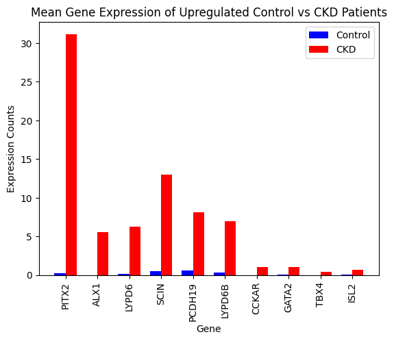

```
PITX2 p=0.01
ALX1 p=0.02
LYPD6 p=0.01
SCIN p=0.01
PCDH19 p=0.01
LYPD6B p=0.01
CCKAR p=0.02
GATA2 p=0.02
TBX4 p=0.02
ISL2 p=0.02
```

```python
#UPREGULATED GENES

#TO GRAPH: calculate means of each gene in control, and ckd patient
means=pd.DataFrame(columns=['Row','MeanC', 'MeanT'])
for i, row in up.iterrows():
   controlmean=row[['22-C','23-C','24-C']].mean()
   tmean=row[['13-E','14-E', '15-E', '16-E','17-E', '18-E', '19-E', '20-E', '21-E']].mean()
   means = pd.concat([means, pd.DataFrame({"Row": [up["Gene_symbol"][i]], "MeanC": [controlmean], "MeanT": [tmean]})], ignore_index=True)

means

#graph the gene expression means of control and ckd patients to see visible differences
bar_width = 0.35
bar1 = np.arange(len(means["Row"]))
bar2 = bar1 + bar_width

plt.bar(bar1, means['MeanC'],width=bar_width, label="Control", color="blue")
plt.bar(bar2, means['MeanT'],width=bar_width,label="CKD", color="red")

plt.xlabel('Gene')
plt.ylabel('Expression Counts')
plt.xticks(bar1+bar_width/2,means["Row"], rotation="vertical")
plt.title('Mean Gene Expression of Upregulated Control vs CKD Patients')
plt.legend()
plt.show()

#HYPOTHESIS TEST
import scipy.stats as stats
from scipy.stats import mannwhitneyu
import numpy as np
control= ['22-C','23-C','24-C']
treatment=['13-E','14-E', '15-E', '16-E','17-E', '18-E', '19-E', '20-E', '21-E']

upc=up[control]
upt=up[treatment]
#TEST ON EACH GENE
stat, p_value = mannwhitneyu(upc.iloc[0], upt.iloc[0])
print( 'PITX2 p=%.2f'%p_value)
stat1, p_value1 = mannwhitneyu(upc.iloc[1], upt.iloc[1])
print( 'ALX1 p=%.2f'%p_value1)
stat2, p_value2 = mannwhitneyu(upc.iloc[2], upt.iloc[2])
print( 'LYPD6 p=%.2f'%p_value2)
stat3, p_value3 = mannwhitneyu(upc.iloc[3], upt.iloc[3])
print( 'SCIN p=%.2f'%p_value3)
stat4, p_value4 = mannwhitneyu(upc.iloc[4], upt.iloc[4])
print( 'PCDH19 p=%.2f'%p_value4)
stat5, p_value5 = mannwhitneyu(upc.iloc[5], upt.iloc[5])
print( 'LYPD6B p=%.2f'%p_value5)
stat6, p_value6 = mannwhitneyu(upc.iloc[6], upt.iloc[6])
print( 'CCKAR p=%.2f'%p_value6)
stat7, p_value7 = mannwhitneyu(upc.iloc[7], upt.iloc[7])
print( 'GATA2 p=%.2f'%p_value7)
stat8, p_value8 = mannwhitneyu(upc.iloc[8], upt.iloc[8])
print( 'TBX4 p=%.2f'%p_value8)
stat9, p_value9 = mannwhitneyu(upc.iloc[9], upt.iloc[9])
print( 'ISL2 p=%.2f'%p_value9)
```

The p-value of all of the genes of interest is <.05, thus we reject our null hypothesis for each one. We can assume the genes of interest all have significant difference in gene expression in the control group compared to CKD patients, thus we can assume a relation to the disease being involved. We also graphed the genes, and looking at it, you can see the CKD patients have visibily higher expression in all of the groups, while the controls have low expression- the genes in CKD are upregulated. We can assume the upregulation is involved in the disease in some relation, as the means are much different in the groups control and CKD patient groups.

```python
#DOWNREGULATED GENES

#TO GRAPH: calculate means of each gene in control, and ckd patient
down=down.head(10)
means=pd.DataFrame(columns=['Row','MeanC', 'MeanT'])
for i, row in down.iterrows():
   controlmean=row[['22-C','23-C','24-C']].mean()
   tmean=row[['13-E','14-E', '15-E', '16-E','17-E', '18-E', '19-E', '20-E', '21-E']].mean()
   means=means.append({"Row":down["Gene_symbol"][i], "MeanC" :controlmean, "MeanT":tmean}, ignore_index=True)

#graph the gene expression means of control and ckd patients to see visible differences
means
bar_width = 0.35
bar1 = np.arange(len(means["Row"]))
bar2 = bar1 + bar_width

plt.bar(bar1, means['MeanC'],width=bar_width, label="Control", color="blue")
plt.bar(bar2, means['MeanT'],width=bar_width,label="CKD", color="red")

plt.xlabel('Gene')
plt.ylabel('Expression Counts')
plt.xticks(bar1+bar_width/2,means["Row"], rotation="vertical")
plt.title('Mean Gene Expression of Downregulated Control vs CKD Patients')
plt.legend()
plt.show()

#HYPOTHESIS TEST

downc=down[control]
downt=down[treatment]

#TEST ON EACH GENE
stat, p_value = mannwhitneyu(downc.iloc[0], downt.iloc[0])
print( 'PKNOX2 p=%.2f'%p_value)
stat1, p_value1 = mannwhitneyu(downc.iloc[1],downt.iloc[1])
print( 'IGFN1 p=%.2f'%p_value1)
stat2, p_value2 = mannwhitneyu(downc.iloc[2], downt.iloc[2])
print( 'ZIC1 p=%.2f'%p_value2)
stat3, p_value3 = mannwhitneyu(downc.iloc[3], downt.iloc[3])
print( 'ZIC4 p=%.2f'%p_value3)
stat4, p_value4 = mannwhitneyu(downc.iloc[4], downt.iloc[4])
print( 'MEGF10 p=%.2f'%p_value4)
stat5, p_value5 = mannwhitneyu(downc.iloc[5],downt.iloc[5])
print( 'EPHA7 p=%.2f'%p_value5)
stat6, p_value6 = mannwhitneyu(downc.iloc[6], downt.iloc[6])
print( 'ADAMTS15 p=%.2f'%p_value6)
stat7, p_value7 = mannwhitneyu(downc.iloc[7],downt.iloc[7])
print(  'ADCY8 p=%.2f'%p_value7)
stat8, p_value8 = mannwhitneyu(downc.iloc[8], downt.iloc[8])
print( 'NEFM p=%.2f'%p_value8)
stat9, p_value9 = mannwhitneyu(downc.iloc[9], downt.iloc[9])
print( 'ZIC2 p=%.2f'%p_value9)
```

[output not shown]

## Part 3: Risk Factor Data Preprocessing

We looked at data on clinical risk factors from patients who have and dont have CKD to understand if one can associate given patterns of risk factors to CKD.

```
sg      0.720520
hemo    0.708267
pcv     0.645611
htn     0.587966
dm      0.587847
rc      0.547426
rbc     0.531511
Name: classification, dtype: float64
```

|  | spec_grav | hemoglobin | packed_cell_vol | red_b_cells | albumin | hypertension | diabetes | ckd_class |
| --- | --- | --- | --- | --- | --- | --- | --- | --- |
| 0 | 1.025000 | 12.6 | 39.0 | 3.9 | 3.0 | 1.0 | 1.0 | 1 |
| 1 | 1.017439 | 11.7 | 41.0 | 4.8 | 0.0 | 0.0 | 1.0 | 1 |
| 2 | 1.017439 | 12.1 | 41.0 | 4.8 | 0.0 | 1.0 | 0.0 | 1 |
| 3 | 1.025000 | 17.8 | 43.0 | 5.5 | 0.0 | 0.0 | 0.0 | 0 |
| 4 | 1.015000 | 11.1 | 39.0 | 4.6 | 4.0 | 1.0 | 0.0 | 1 |
| ... | ... | ... | ... | ... | ... | ... | ... | ... |
| 275 | 1.010000 | 9.8 | 28.0 | 3.2 | 1.0 | 1.0 | 1.0 | 1 |
| 276 | 1.017439 | 6.0 | 17.0 | 4.8 | 0.0 | 1.0 | 1.0 | 1 |
| 277 | 1.025000 | 14.3 | 41.0 | 5.0 | 0.0 | 0.0 | 0.0 | 0 |
| 278 | 1.020000 | 13.6 | 44.0 | 6.4 | 0.0 | 0.0 | 0.0 | 0 |
| 279 | 1.010000 | 13.9 | 52.0 | 4.8 | 0.0 | 0.0 | 0.0 | 1 |

280 rows × 8 columns

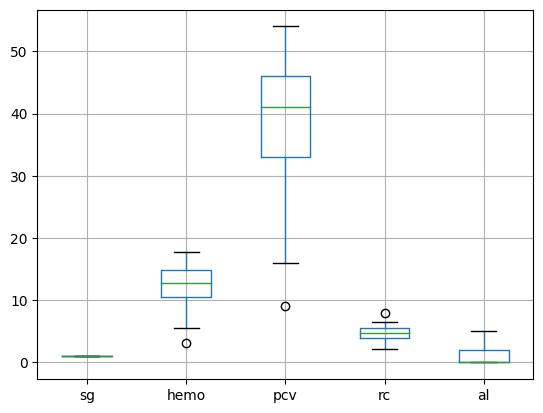

```python
import pandas as pd
import matplotlib.pyplot as plt
import seaborn as sns
from scipy.stats import pearsonr

rf_df = pd.read_csv("kidney_disease_train.csv")
rf_df
rf_df.columns

# changing categorical variables to have numerical values
rf_df['classification'] = rf_df['classification'].replace({'ckd': 1, 'notckd': 0})
rf_df['rbc'] = rf_df['rbc'].replace({'abnormal': 1, 'normal': 0})
rf_df['pc'] = rf_df['pc'].replace({'abnormal': 1, 'normal': 0})
rf_df['pcc'] = rf_df['pcc'].replace({'present': 1, 'notpresent': 0})
rf_df['ba'] = rf_df['ba'].replace({'present': 1, 'notpresent': 0})
rf_df['htn'] = rf_df['htn'].replace({'yes': 1, 'no': 0})
rf_df['dm'] = rf_df['dm'].replace({'yes': 1, 'no': 0})
rf_df['cad'] = rf_df['cad'].replace({'yes': 1, 'no': 0})
rf_df['appet'] = rf_df['appet'].replace({'poor': 1, 'good': 0})
rf_df['pe'] = rf_df['pe'].replace({'yes': 1, 'no': 0})
rf_df['ane'] = rf_df['ane'].replace({'yes': 1, 'no': 0})

# converting object columns to floats
rf_df.dtypes
rf_df[['wc', 'rc', 'dm', 'cad']] = rf_df[['wc', 'rc', 'dm', 'cad']].applymap(lambda x: pd.to_numeric(x, errors='coerce'))
rf_df['wc'] = rf_df['wc'].astype(float)
rf_df['rc'] = rf_df['rc'].astype(float)
rf_df['dm'] = rf_df['dm'].astype(float)
rf_df['cad'] = rf_df['cad'].astype(float)

# for columns with less than 10% of data missing, replace with mean
rf_df.shape # (280, 26)
for col in rf_df.columns:
  # print(col, ":", sum(rf_df[col].isna()))
  if(sum(rf_df[col].isna()) <= 28):
    avg = rf_df[col].mean()
    rf_df[col].fillna(avg, inplace=True)

# replacing null values with mean if the data is normally distributed, median if skewed
rf_df.boxplot(['sg', 'hemo', 'pcv', 'rc', 'al'])

# 'sg' is normally ditributed, so replace missing values with the mean
rf_df['sg'].fillna(rf_df['sg'].mean(), inplace=True)

# 'hemo', 'pcv', and 'rc' are all negatively skewed and have one outlier. 'al' is heavily positively skewed.
# Replace missing data with median
for col in ['hemo', 'pcv', 'rc', 'al']:
  med = rf_df[col].median()
  rf_df[col] = rf_df[col].apply(lambda x: med if pd.isnull(x) else x)

# To determine which variables are important to analyze, we want to see which variables have the most correlation with the 'classification'.
corr = rf_df.corr()
# sns.heatmap(corr, annot = True)

# getting the top 5 correlated variables with the 'classification' column (ckd or notckd)
corr_with_class = corr['classification'].abs()
corr_with_class = corr_with_class.drop('classification')
corr_with_class = corr_with_class.drop('id')
top_7 = corr_with_class.nlargest(7)
print(top_7)
# The 7 strongest correlated variables are 'sg' (0.7579), 'hemo' (0.7560), 'pcv' (0.7276), 'rc' (0.6833), 'al' (0.6354), 'htn' (0.5879), and 'dm' (0.5878).

# keep only the columns of interest
rf_df = rf_df[['sg', 'hemo', 'pcv', 'rc', 'al', 'htn', 'dm', 'classification']]
# rename columns for clarity
new_cols = ['spec_grav', 'hemoglobin', 'packed_cell_vol', 'red_b_cells', 'albumin', 'hypertension', 'diabetes', 'ckd_class']
rf_df.columns = new_cols
rf_df
```

## Part 4: Exploratory Data Analysis for Risk Factor Data

**1. Chi-Squared Test**

> Null Hypothesis: The level of specific gravity does not effect the likelihood of having chronic kidney disease.

> Alternative Hypothesis: The level of specific gravity does have an effect on the likelihood of having chronic kidney disease.

[output not shown]

[figure not shown]

```
P-value: 2.5067102255591784e-37
```

```python
contingency_table = pd.crosstab(rf_df['spec_grav'], rf_df['ckd_class'])
print("Contingency Table:")
print(contingency_table)

grouped = rf_df.groupby(['spec_grav', 'ckd_class']).size().unstack()
plot = grouped.plot(kind='bar', stacked=True, figsize=(10, 6))
plt.title('Counts of ckd vs nonckd cases by specific gravity level')
plt.xlabel('specific gravity')
plt.ylabel('Count')
plt.show()

from scipy.stats import chi2_contingency

chi2, p_value, _, _ = chi2_contingency(contingency_table)
print(f"P-value: {p_value}")
```

The plot above shows the relationship between the sg level and the ckd classification. It shows that the lower sg levels had more cases classified as ckd.

After running the Chi-Squared Test, we get a p-value of 2.507e-37. Based on the obtained p-value, we reject the null hypothesis because the p-value is less than the significance level: 2.507e-37 < 0.01. Therefore, we can conclude that the sg level does indeed have an effect on whether or not someone has chronic kidney disease.

**2. ANOVA Test**

> Null Hypothesis: The mean number of cases of chronic kidney disease are about the same among the different groups of sg levels.

> Alternative Hypothesis: The mean number of cases of chronic kidney disease are different among at least 2 different groups of sg levels.

```
P-value: 4.19183799931205e-60
```

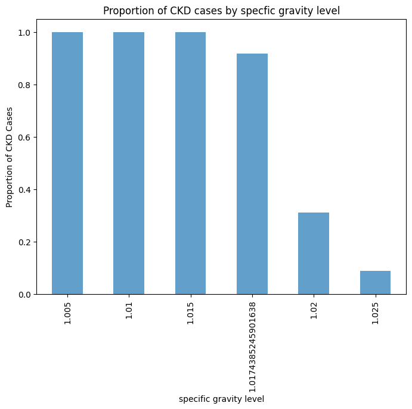

```python
from scipy.stats import f_oneway

# anova test
groups = [rf_df[rf_df['spec_grav'] == sg_level]['ckd_class'] for sg_level in rf_df['spec_grav'].unique()]
f_statistic, p_value = f_oneway(*groups)
print(f"P-value: {p_value}")

# plotting proportion of ckd cases within each sg level category
csg = rf_df.groupby('spec_grav')['ckd_class'].mean()

plt.figure(figsize=(8, 6))
csg.plot(kind='bar', alpha=0.7)
plt.title('Proportion of CKD cases by specfic gravity level')
plt.xlabel('specific gravity level')
plt.ylabel('Proportion of CKD Cases')
plt.show()
```

The plot above shows the proportion of ckd cases by sg level. It shows that with low levels of sg (1.005, 1.01, and 1.015), 100% of the patients have ckd.

The p-value produced by the ANOVA test is 4.1918e-60. This is very small and less than the significance level of 0.01. Therefore, we reject the null hypothesis and conclude that the mean number of ckd cases based on sg level is indeed different. This implies that lower levels of sg result in ckd.

A Post Hoc Test can be helpful to identify which specific groups are different from each other and how they are different. For example, if people with a sg level of 1.005 are more likely to have ckd compared to people with a sg level of 1.01 and so on. However, we will not conduct a post hoc test for this project because we are only interested in the general features that have most impact when predicting ckd, rather than the specific differences within a single feature.

We can conclude from this exploratory analysis that ckd can be predicted from low levels of sg, specifically, sg levels of 1.005, 1.01, 1.015, and 1.0174.

## Part 5: Machine Learning for Risk Factor Data

Before we can use the SVM method, we need to normalize the data to deal with high variation and noise which could negatively effect the accuracy of the model. Here, we use z-score normalization due to the wide range of values that the numerical variables have.

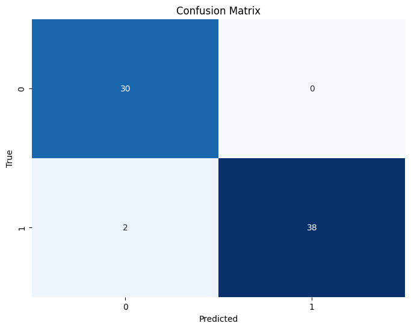

```python
import matplotlib.pyplot as plt
import numpy as np
import pandas as pd
import seaborn as sns
from sklearn import svm
from sklearn.model_selection import train_test_split
from sklearn.metrics import confusion_matrix
from sklearn.preprocessing import StandardScaler

X = rf_df[['spec_grav', 'hemoglobin', 'packed_cell_vol', 'red_b_cells', 'albumin', 'hypertension', 'diabetes']].values
Y = rf_df[['ckd_class']].values

# Split the data into training and testing sets.
X_train, X_test, Y_train, Y_test = train_test_split(X, Y, random_state=20220621)

# Scale the input variable because SVM is dependent on differences in scale for distances
scaler = StandardScaler()
X_train_scaled = scaler.fit_transform(X_train)
X_test_scaled = scaler.transform(X_test)

# Define and fit the risk factor SVM model
rfSVMlinear = svm.SVC(kernel='linear', C=0.01)
rfSVMlinear.fit(X_train_scaled, Y_train)

# Predict for the test set
Y_pred = rfSVMlinear.predict(X_test_scaled)

# Display the confusion matrix
cm = confusion_matrix(Y_test, Y_pred)

plt.figure(figsize=(8, 6))
sns.heatmap(cm, annot=True, fmt='d', cmap='Blues', cbar=False)
plt.title('Confusion Matrix')
plt.xlabel('Predicted')
plt.ylabel('True')
plt.show()
```

```python
from sklearn.metrics import classification_report

report = classification_report(Y_test, Y_pred)
print("Classification Report:")
print(report)
```

```
Classification Report:
              precision    recall  f1-score   support

           0       0.94      1.00      0.97        30
           1       1.00      0.95      0.97        40

    accuracy                           0.97        70
   macro avg       0.97      0.97      0.97        70
weighted avg       0.97      0.97      0.97        70
```

Based on the classification report generated by sklearn, we can observe that the precision is 100%, the recall is 95%, and the f1-score is 0.97. These high statistics indicate that the SVM model generally classifies cases of chronic kidney disease accurately.

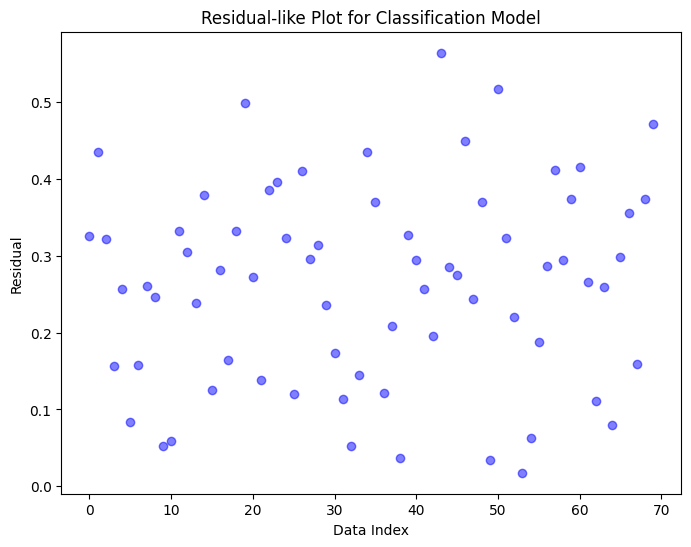

```python
import numpy as np
import matplotlib.pyplot as plt

# Calculate decision function scores for the test set
decision_scores = rfSVMlinear.decision_function(X_test_scaled)

# Convert decision scores to probabilities using a sigmoid function
Y_pred_proba = 1 / (1 + np.exp(-decision_scores))

# Calculate and plot residuals
residuals = np.abs(Y_pred_proba - Y_test.flatten())

plt.figure(figsize=(8, 6))
plt.scatter(range(len(Y_test)), residuals, color='blue', alpha=0.5)
plt.title('Residual-like Plot for Classification Model')
plt.xlabel('Data Index')
plt.ylabel('Residual')
plt.show()
```

In the above residual plot, the residuals are shown to be scattered and have no particular pattern. This demonstrates the fact that the SVM model's predictions are random, and therefore are not systematically biased toward overestimating or underestimating the true probabilities. This further suggests that this model is performing reasonably well.

# ML Gene Data

```python
import matplotlib.pyplot as plt
import numpy as np
import pandas as pd
import seaborn as sns
from sklearn import svm
from sklearn.model_selection import train_test_split
from sklearn.metrics import confusion_matrix
from sklearn.preprocessing import StandardScaler

import pandas as pd
from sklearn.model_selection import train_test_split
from sklearn.preprocessing import StandardScaler
from sklearn.linear_model import LogisticRegression
from sklearn.metrics import accuracy_score

# Step 1: Load and preprocess the gene expression data
  # Replace with the path to your gene expression data file

# Separate the control and disease groups

x=['13-E','14-E', '15-E', '16-E','17-E', '18-E', '19-E', '20-E', '21-E']
y=['22-C','23-C','24-C']
gene_column = 'gene_name'

X = gene_df[x + y]  # Input features (gene expression levels)
y = gene_df["Gene_symbol"]  # Target variable (gene name)

# Step 2: Split the data into training and test sets
X_train, X_test, y_train, y_test = train_test_split(X, y, test_size=0.2, random_state=42)

# Step 3: Scale the input features
scaler = StandardScaler()
X_train_scaled = scaler.fit_transform(X_train)
X_test_scaled = scaler.transform(X_test)

# Step 4: Create and train the model
model = LogisticRegression()
model.fit(X_train_scaled, y_train)

# Step 5: Make predictions on the test set
y_pred = model.predict(X_test_scaled)

# Step 6: Evaluate the model
accuracy = accuracy_score(y_test, y_pred)
print("Accuracy:", accuracy)
```

```
Accuracy: 0.0
```

```python
import matplotlib.pyplot as plt
import numpy as np
import pandas as pd
import seaborn as sns
from sklearn import svm
from sklearn.model_selection import train_test_split
from sklearn.metrics import confusion_matrix
from sklearn.preprocessing import StandardScaler
x = gene_df[treatment].values
y =gene_df[['22-C','23-C','24-C']].values

# Split the data into training and testing sets.
X_train, X_test, Y_train, Y_test = train_test_split(x, y, random_state=20220621)


x=gene_df[['13-E','14-E', '15-E', '16-E','17-E', '18-E', '19-E', '20-E', '21-E'].values()
control=['22-C','23-C','24-C']
```

[output not shown]